# Best Time to Visit Beijing

Cheng Jiechao - WQD180050  
Teng Lung Yun - WQD180024  
Pau Kah Ho - WQD180037  
Yong Wai Shin - WQD180063  
WQD7001 - PRINCIPLES OF DATA SCIENCE

10 December, 2018

# Introduction

**Background**

Here we present an intuitive Shiny App to visualize the weather data of Beijing City. There are several features used to describe the weather of Beijing. We will find the optimal time to visit Beijing based on personal choices.

- Shiny App: https://stephen-cheng.shinyapps.io/Best-Time-to-Visit-Beijing/
- Github Code: https://github.com/jetrobert/Best-Time-to-Visit-Beijing
- Data source: http://archive.ics.uci.edu/ml/datasets/Beijing+PM2.5+Data#

**Problem Statement**

My friends and I are planning to visit Beijing. The weather in Beijing, however, is different compared to Malaysia. Therefore, we want to identify the best time to visit Beijing.

**Objective**

- To gain insight into Beijing’s historical meteorological data.
- To identify the best time to visit Beijing.

# Data Collection

Our dataset is obtained from UCI https://archive.ics.uci.edu/ml/datasets/Beijing+PM2.5+Data

- The dimension of our dataset:

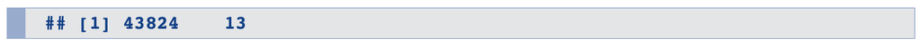

- The features of our dataset are as follows:
1. PM2.5: Particulate Matter 2.5,
2. DEWP: Dew Point,
3. TEMP: Temperature,
4. PRES: Pressure,
5. cbwd: Combined wind direction,
6. Iws: Cumulated wind speed (m/s),
7. Is: Cumulated hours of snow,
8. Ir: Cumulated hours of rain.

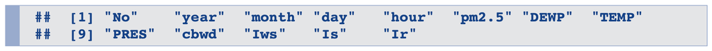

- Our dataset looks like:

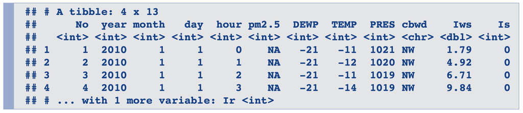

# Data Pre-processing

1.Drop all NAs in the dataset.

2.Select meaningful columns and drop the No. column.

(* The data pre-processing is implemented in RStudio.)

- The dimension of pre-processed dataset:

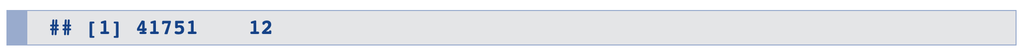

- The pre-processed dataset looks like:

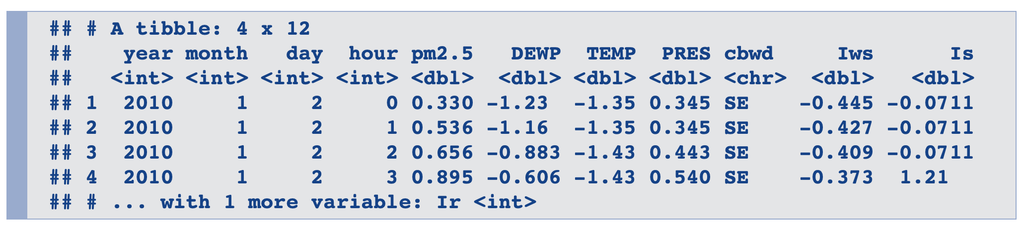

# Data Analysis & Knowledge Insights

1.The clustering results of time will be changed if the features are different.

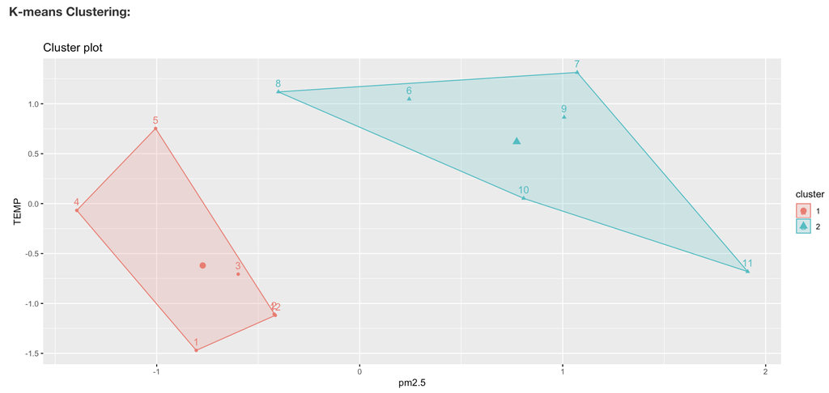

4.If you don’t care about pm2.5 or temperature but other features, you may have different time recommendation.